# Crisis and disaster risks around the world

Berkay Ocak & Ezgi Özgen

Ocak 29, 2022

When natural disasters around the world are considered, 28 of 31 natural disasters are seen as meteorological disasters. The 10 most natural disasters is:  
1. Agricultural diseases & pests  
2. Damaging Winds  
3. Earthquakes  
4. Emergency diseases (pandemic influenza)  
5. Floods and flash floods  
6. Hurricanes and tropical storms  
7. Thunderstorms and lighting  
8. Tornadoes  
9. Tsunamis  
10. Winter and ice storms

# Problem Description

The causes and consequences of natural disasters can be more than one. Natural disasters can cause epidemics and infectious diseases. It delays or stops the investment plans of the state. One of the biggest effects of disasters is that they cause death, injury and disability. Natural disasters can cause trauma to people because they create a shock effect on people. Before natural disasters begin, their severity or impact may not be predicted. It can disrupt the economic order and infrastructure of the region where it occurs. The types and order of importance of natural disasters also vary from country to country. Natural disasters may not just happen spontaneously. There are also human effects. Natural disasters are a threat to the whole world because it is not clear when they will come. It is important to analyze how crisis and disaster risk has changed and where a new or worsening crisis may arise.

# Project Problem

Our main problem is that the countries are not prepared for the disasters they may experience and that they do not learn from the past disasters.  
The aim of our project is to analyze and interpret the future forecast data for 2022 by drawing attention to which disasters and risk ratios countries face.

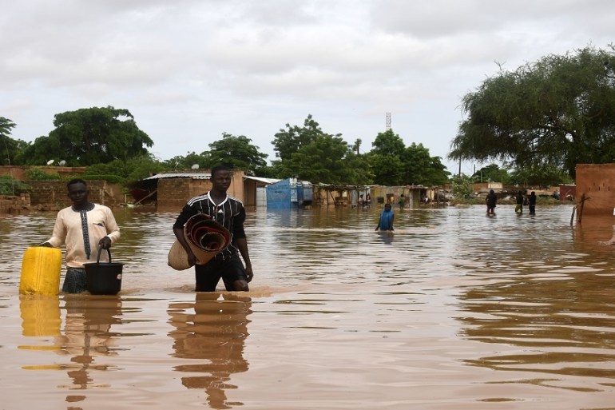

# Data Description and Access Data

We got our data from the official website of the European Commission. According to the European Com- mission, this given meeting purpose”The INFORM Risk Index is a global, open-source risk assessment for humanitarian crises and disasters. It can support decisions about prevention, preparedness and response.”We also chose this catastrophe as the foundation for and design of this modification. On the one hand, the IN- FORM Risk model balances two key forces: the hazard and exposure dimension, and on the other, the vulnerability and lack of coping capacity aspects. Hazard dependent factors are treated in the hazard & exposure dimension, whereas hazard independent factors are divided into two dimensions: vulnerability, which considers the strength of individuals and households in the face of a crisis, and lack of coping capacity, which considers institutional strength.

```r
library("readr")
library("readxl")
library("tidyverse")
library("tidyr")
library("ggpubr")
data <- read_xlsx("Data/INFORMRISK_2022.xlsx")
data_Hazard_exposure <-read_xlsx("Data/Hazard&exposure.xlsx")
data_Indıcatordata <- read_xlsx("Data/Indicatordata.xlsx")
data_LackOfRealibilty <- read_xlsx("Data/LackOfRealibilty.xlsx")
data_LackOfcopincapacity <- read_xlsx("Data/LackOfcopincapacity.xlsx")
data_Regions <- read_xlsx("Data/Regions.xlsx")
data_Vulnerability <- read_xlsx("Data/Vulnerability.xlsx")
data_WorldRiskIndex2011_2021<-
                read_xlsx("Data/WorldRiskIndex2011-2021_time_series.xlsx",skip = 2)
```

**Data visualization**

Types of graphics we used in this project:  
* World Map  
* Lollipop Plots  
* Bar Plot

```r
library(sf)
worldregion<-st_read("data/World_Continents")
```

```r
worldregion<-worldregion %>%
  rename("UNGeographicalRegion"="continent")
```

```r
data_Regions2<- data_count %>%
  select("UNGeographicalRegion","COUNTRY")%>%
  group_by(UNGeographicalRegion)%>%
  summarise(count = n())

deneme = merge(data_Regions2, worldregion, by="UNGeographicalRegion")


tablo<-st_as_sf(deneme)
tablo <- tablo %>%
    group_by(UNGeographicalRegion)%>%
  summarise(count = n())

st_geometry_type(tablo)
```

```
## [1] MULTIPOLYGON MULTIPOLYGON MULTIPOLYGON MULTIPOLYGON MULTIPOLYGON
## 18 Levels: GEOMETRY POINT LINESTRING POLYGON MULTIPOINT ... TRIANGLE
```

```r
library(tmap)

map11 <- tablo %>%
          tm_shape() +
          tm_fill(col = "count",
                  palette = "Spectral",
                  title = "country distribution by region") +
          tm_borders() +
          tm_layout(title = "count of country",
                    title.size = 1,
                    title.fontface = "bold",
                    legend.title.size = 0.6,
                    legend.outside = TRUE)
```

Continental distribution of countries in our data:

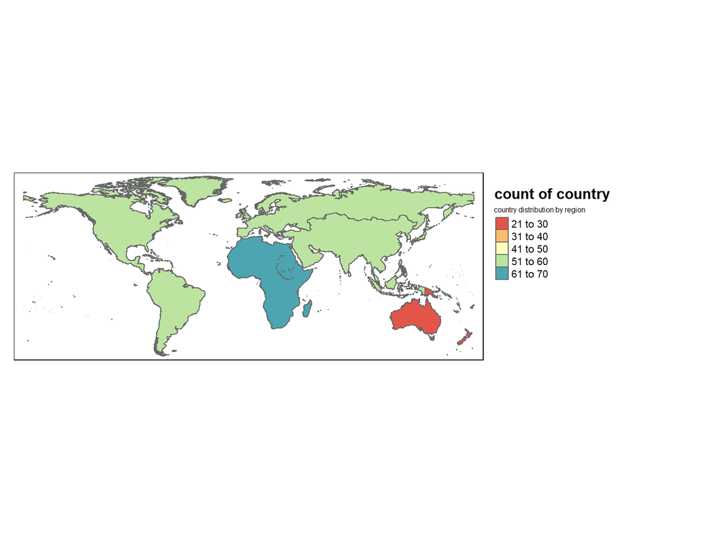

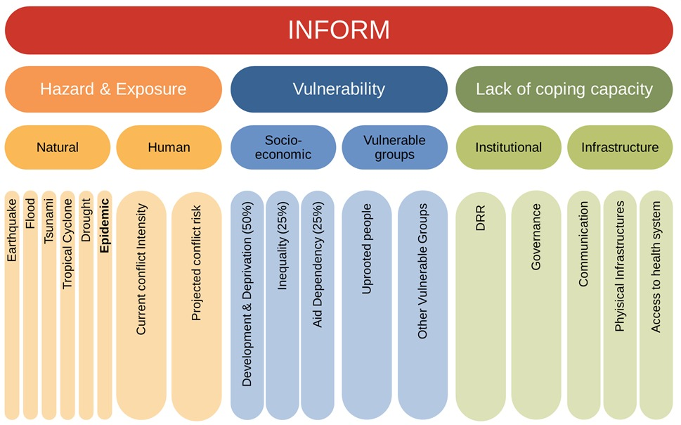

**Hazard & Exposure**  
It is calculated as a result of physical exposure to hazard and exposure risks. It measures that people who are exposed to these events have to take when faced with a disaster or crisis. It is calculated with the subcomponents we showed in the previous slide.  
**Vulnerability**  
It focuses on the material and moral damage that disasters cause on people. Calculates exactly how much the exposed community is affected and how sensitive it is. This ratio indicates the economic, political and social characteristics.  
**Lack Of Coping Capacity**  
It is the fail rate of the measures taken by governments and the community against disaster risks. It shows the resilience of the society. If this rate is high, it is bad for countries.

The chart below shows the risk ratios of the countries we will examine:

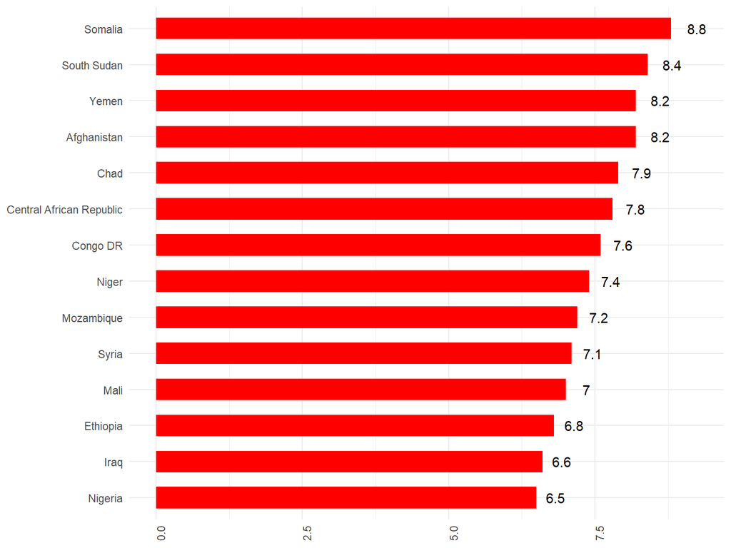

Human population affected by disasters:

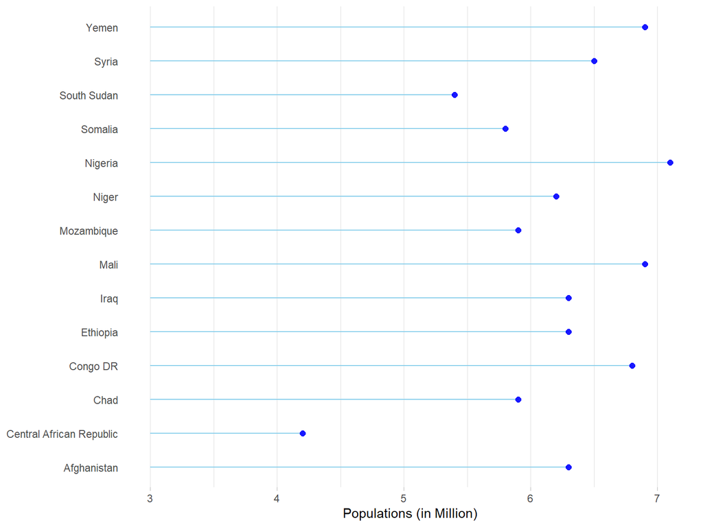

Natural and Human Hazards graphs:

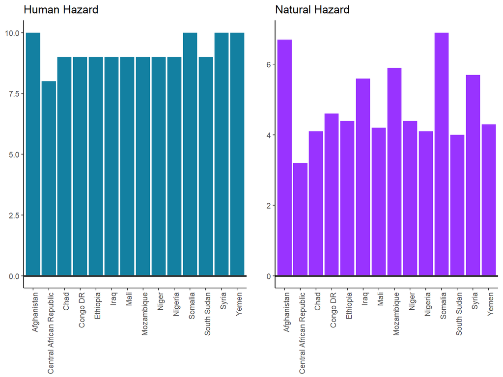

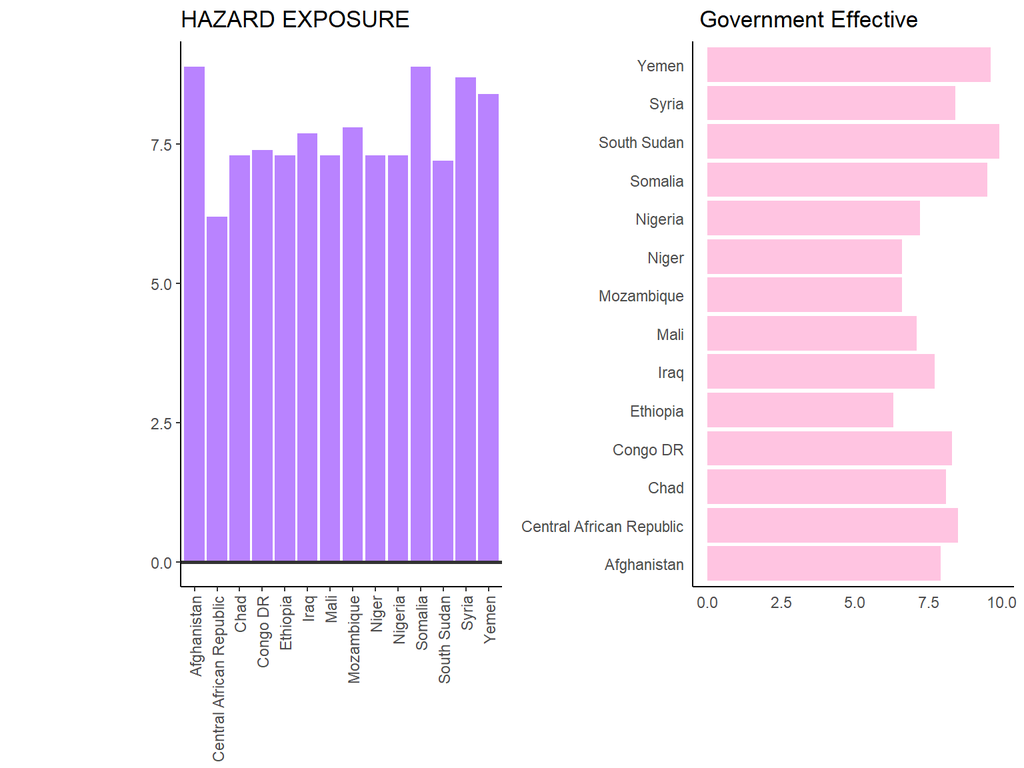

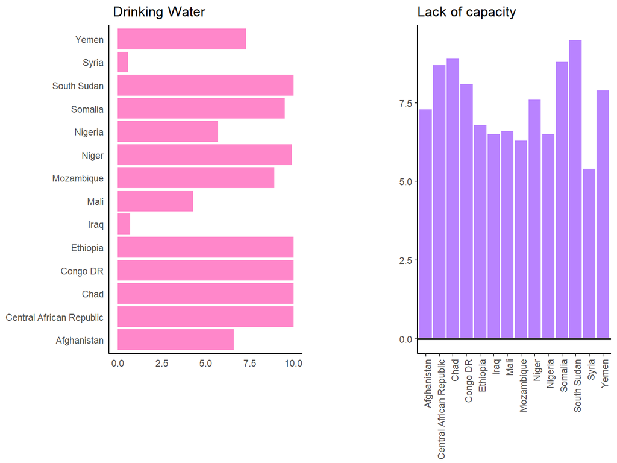

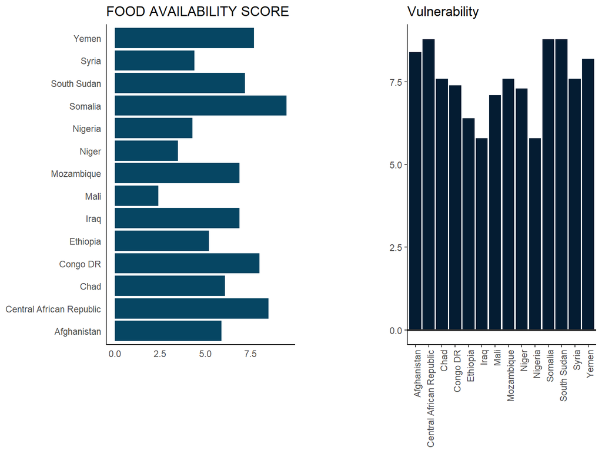

Let’s examine the countries according to the activities they encounter within themselves:

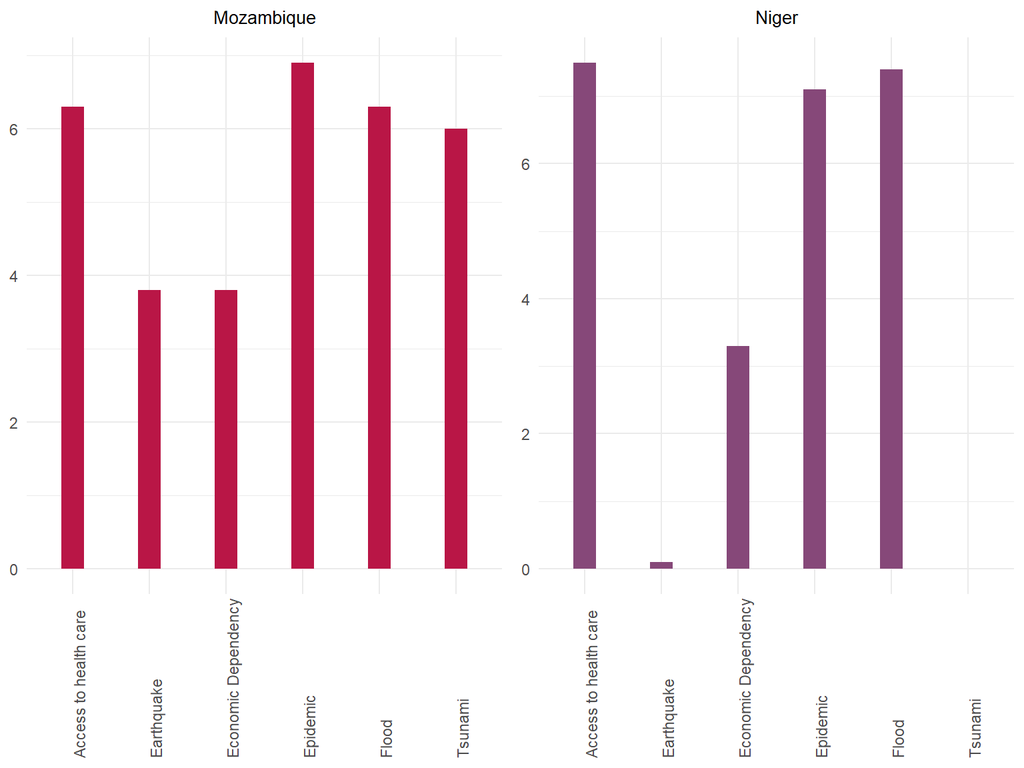

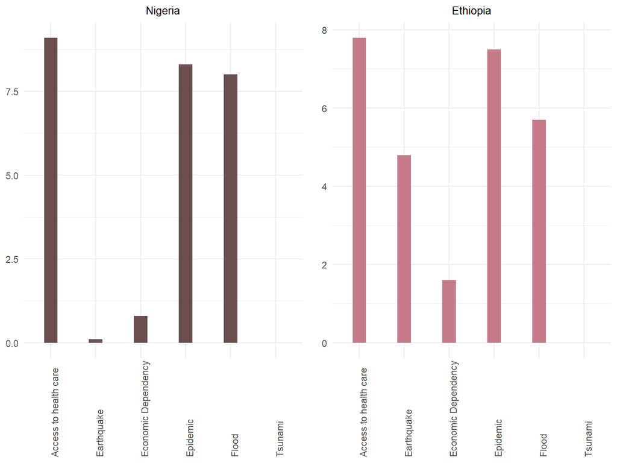

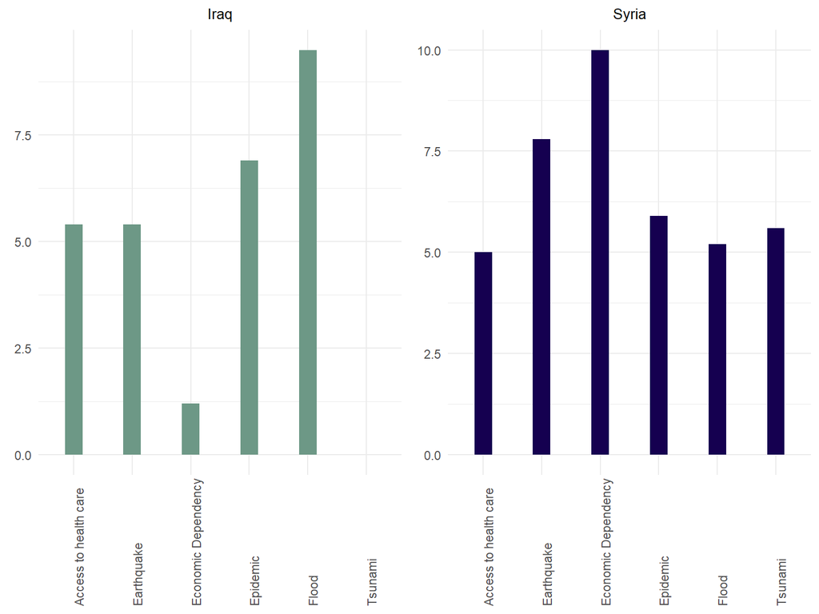

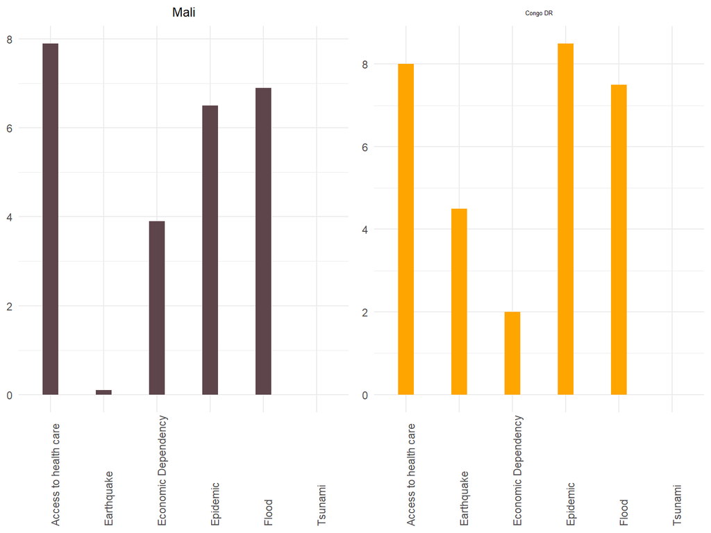

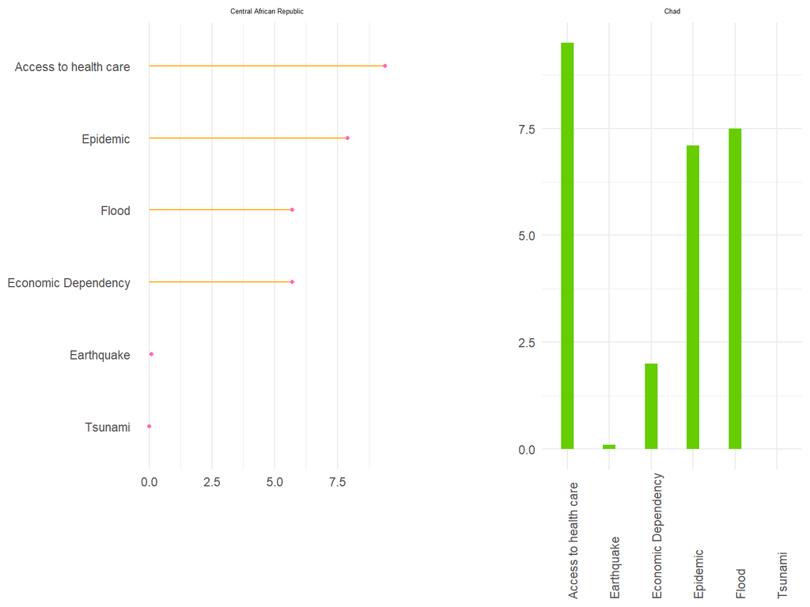

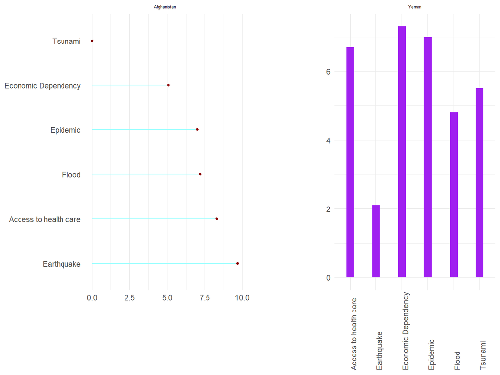

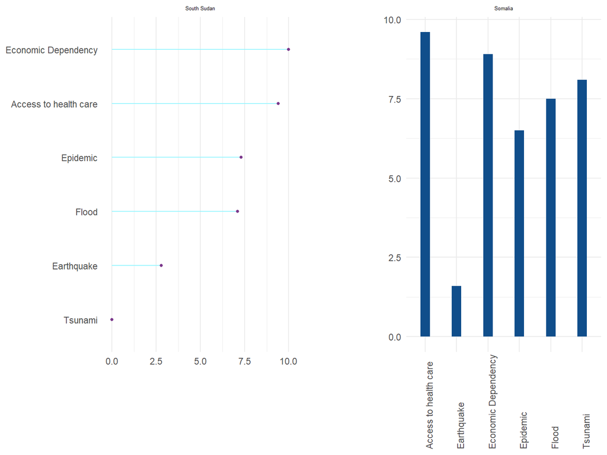

# Missing & Dirty Data

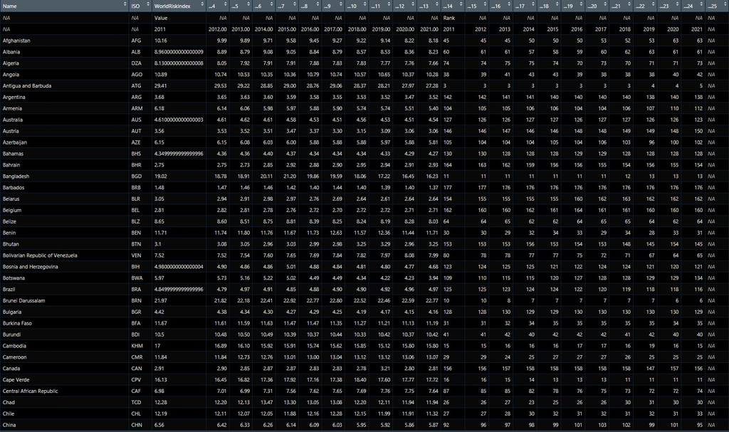

```r
data_OldRisk<-data_WorldRiskIndex2011_2021%>%
  select("...1","2021...13","2021...36","2021...59","2021...128")%>%
  rename("COUNTRY" = "...1")%>%
  rename("RiskValue" = "2021...13")%>%
  rename("HazardExposure" = "2021...36")%>%
  rename("Vulnerability" = "2021...59")%>%
  rename("LackOfCapacity" = "2021...128")%>%
  filter(COUNTRY %in% c("Somalia","South Sudan", "Yemen", "Afghanistan","Chad", "Central African Republic", "Congo DR", "Niger","Mozambique","Syria","Mali", "Ethiopia", "Iraq","Nigeria"))

data_OldRisk$HazardExposure = (data_OldRisk$HazardExposure*5/10)
data_OldRisk$Vulnerability = (data_OldRisk$Vulnerability/10)
data_OldRisk$LackOfCapacity = (data_OldRisk$LackOfCapacity/10)
data_OldRisk$RiskValue = round((data_OldRisk$LackOfCapacity*(1/3)+data_OldRisk$Vulnerability*(1/3)+data_OldRisk$HazardExposure*(1/3)),1)
```

We compared last year’s risks with this year’s risks :

2022 Inform Risk Data

| InformRisk | Country | lackOfCapacity | Vulnerability | HazardExposure |
| --- | --- | --- | --- | --- |
| 8.2 | Afghanistan | 7.3 | 8.4 | 8.9 |
| 7.8 | Central African Republic | 8.7 | 8.8 | 6.2 |
| 7.9 | Chad | 8.9 | 7.6 | 7.3 |
| 7.6 | Congo DR | 8.1 | 7.4 | 7.4 |
| 6.8 | Ethiopia | 6.8 | 6.4 | 7.3 |
| 6.6 | Iraq | 6.5 | 5.8 | 7.7 |
| 7.0 | Mali | 6.6 | 7.1 | 7.3 |
| 7.2 | Mozambique | 6.3 | 7.6 | 7.8 |
| 7.4 | Niger | 7.6 | 7.3 | 7.3 |
| 6.5 | Nigeria | 6.5 | 5.8 | 7.3 |
| 8.8 | Somalia | 8.8 | 8.8 | 8.9 |
| 8.4 | South Sudan | 9.5 | 8.8 | 7.2 |
| 7.1 | Syria | 5.4 | 7.6 | 8.7 |
| 8.2 | Yemen | 7.9 | 8.2 | 8.4 |

2021 Inform Risk Data

| COUNTRY | RiskValue | HazardExposure | Vulnerability | LackOfCapacity |
| --- | --- | --- | --- | --- |
| Afghanistan | 7.3 | 6.135 | 6.663 | 9.140 |
| Central African Republic | 7.2 | 5.040 | 7.583 | 9.056 |
| Chad | 8.2 | 7.880 | 7.575 | 9.216 |
| Ethiopia | 7.1 | 5.875 | 6.752 | 8.735 |
| Iraq | 6.5 | 5.200 | 5.577 | 8.789 |
| Mali | 7.8 | 7.805 | 6.864 | 8.860 |
| Mozambique | 7.4 | 6.630 | 6.873 | 8.845 |
| Niger | 8.5 | 9.635 | 7.215 | 8.791 |
| Nigeria | 8.4 | 9.820 | 6.446 | 8.858 |
| Yemen | 6.8 | 4.135 | 6.912 | 9.317 |

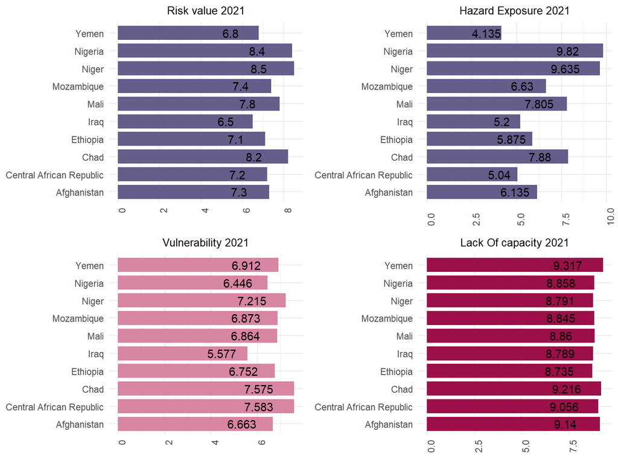

Now let’s examine Turkey’s risk ratios by comparing them with high-risk countries.

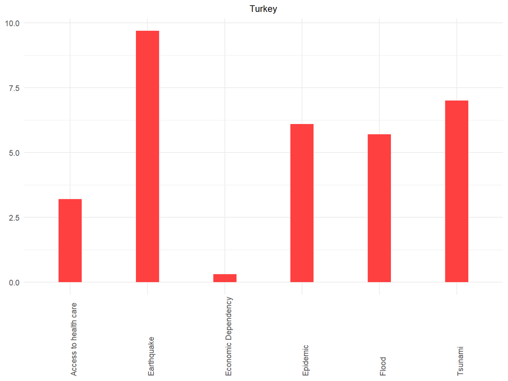

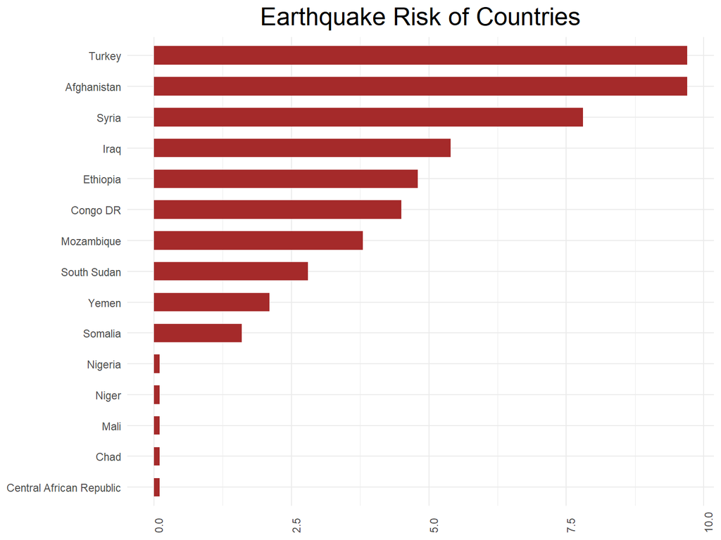

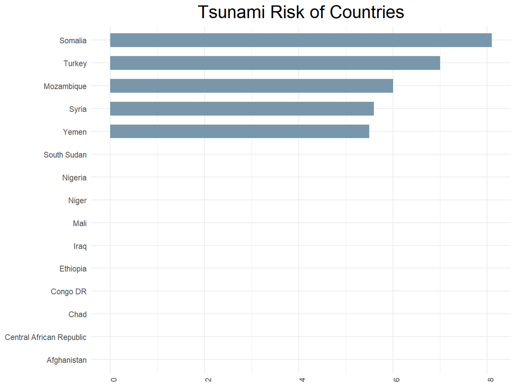

# Challanges

We had difficulty cleaning data with missing data. Since there is a lot of data that connects each other, we decided how to proceed by doing long research in the process.

[figure not shown]

# Conclusion

# References

https://afad.gov.tr/

https://www.readcube.com/articles/10.4314%2Fjasem.v13i2.55295 [1]

http://www.koeri.boun.edu.tr/sismo/2/tsunami/tarihsel-tsunamiler/turkiyedeki-onemli-tsunamiler

https://tr.wikipedia.org

https://drmkc.jrc.ec.europa.eu/inform-index/INFORM-Risk/Results-and-data/moduleId/1782/id/433/controller/Admin/action/Results.

https://thinkhazard.org/en/report/170-mozambique/TS

https://www.google.com/url?sa=i&url=https%3A%2F%2Fwww.fbu.edu.tr%2Fakademik%2F176%2Fkodlama-teknolojik-okur-yazarlik&psig=AOvVaw1oaIZqFtzHyd6xZr3QMnMp&ust=1643495449945000&source=images&cd=vfe&ved=0CAsQjRxqFwoTCPDk2eq_1fUCFQAAAAAdAAAAABAD

https://www.google.com/url?sa=i&url=https%3A%2F%2Fwww.aljazeera.com%2Fnews%2F2020%2F8%2F29%2Fniger-flooding-at-least-45-killed-226000-displaced&psig=AOvVaw2D9U_BqB3xQrQ-tzB8703c&ust=1643495502315000&source=images&cd=vfe&ved=0CAsQjRxqFwoTCKirsoDA1fUCFQAAAAAdAAAAABAD

https://www.google.com/url?sa=i&url=https%3A%2F%2Fggplot2.tidyverse.org%2F&psig=AOvVaw2CcOYXSBpyd3UH2gMvT-ka&ust=1643496994561000&source=images&cd=vfe&ved=0CAsQjRxqFwoTCKDhiMjF1fUCFQAAAAAdAAAAABAK